# Tier 3 Differential Expression Analysis (Hybrid Inheritance)

Carlota Myhre de Gouveia

2026-04-24

## Introduction

Tier 3 focuses on expression inheritance in corkwing wrasse hybrids across three temperature treatments (12°C, 15°C, and 18°C). By comparing hybrid expression profiles with those of the South and West parental populations, transcripts were classified into inheritance categories including conserved, additive, parent-like, and misexpressed expression patterns.

Differential expression analyses were performed between hybrids and each parental population, as well as between parental populations within each temperature treatment. These contrasts were then used to classify transcripts according to their inheritance pattern and to evaluate how these patterns vary across temperatures.

The objectives of this analysis were to:

1. Classify transcripts according to patterns of expression inheritance in hybrids.
2. Evaluate the consistency of inheritance patterns across temperatures.
3. Compare Tier 3 candidate genes with those identified in Tier 1 (conserved temperature responses) and Tier 2b (local adaptation candidates).

## Package Loading

```r
suppressPackageStartupMessages({
  library(tidyverse)
  library(DESeq2)
  library(ashr)
  library(readxl)
  library(rlang)
  library(ggVennDiagram)
  library(DT)
    library(here)
    library(ggplot2)
    library(patchwork)
})
```

## Data Import and Preprocessing

```r
## Define isoform-level abundance files
counts_file <- "results/assembly/trinity/abundance_estimation/compiled_abundance/abundance_matrix_isoforms.isoform.counts.matrix"
tpm_file    <- "results/assembly/trinity/abundance_estimation/compiled_abundance/abundance_matrix_isoforms.isoform.TPM.not_cross_norm"

## Load raw matrices
counts_raw <- read.delim(counts_file, header = TRUE, sep = "\t", check.names = FALSE)
tpm_raw    <- read.delim(tpm_file,    header = TRUE, sep = "\t", check.names = FALSE)

# Fix first column name
colnames(counts_raw)[1] <- "isoform"
colnames(tpm_raw)[1]    <- "isoform"

# Remove metadata column if present
counts_raw <- counts_raw[, !colnames(counts_raw) %in% "abundance_estimation"]
tpm_raw    <- tpm_raw[, !colnames(tpm_raw) %in% "abundance_estimation"]

# Set isoform IDs as rownames
rownames(counts_raw) <- counts_raw$isoform
rownames(tpm_raw)    <- tpm_raw$isoform

# Drop the isoform column
counts_raw <- counts_raw[, -1]
tpm_raw    <- tpm_raw[, -1]

# Convert to numeric safely
abundance_matrix <- as.data.frame(lapply(counts_raw, as.numeric))
tpm_matrix       <- as.data.frame(lapply(tpm_raw,    as.numeric))

rownames(abundance_matrix) <- rownames(counts_raw)
rownames(tpm_matrix)       <- rownames(tpm_raw)

# Remove rows with any NA
keep_complete <- complete.cases(abundance_matrix) & complete.cases(tpm_matrix)
abundance_matrix <- abundance_matrix[keep_complete, ]
tpm_matrix       <- tpm_matrix[keep_complete, ]

# Fix sample names to match Excel metadata
colnames(abundance_matrix) <- sub(".*Melops", "", colnames(abundance_matrix))
colnames(tpm_matrix)       <- sub(".*Melops", "", colnames(tpm_matrix))


# Load sample metadata from Excel
sample_info <- readxl::read_excel("data/sample_conditions_rnaseq.xlsx") %>%
  mutate(
    sample = sub("L", "", RNA_Later_ID),   # create 'sample' column to match abundance matrix
    origin = factor(Origin, levels = c("W","H","S")),
    temperature = factor(`Temperature (celsius)`, levels = c(12,15,18)),
    condition = factor(RNAseqgroup,
                       levels = c("W12","W15","W18",
                                  "H12","H15","H18",
                                  "S12","S15","S18")),
    length = scale(`Total length (mm)`)
  ) %>%
  select(sample, origin, temperature, condition, length) %>%
  arrange(match(sample, colnames(abundance_matrix)))

# Preview matrices and metadata
knitr::kable(abundance_matrix[1:10, 1:10],
             caption = "Isoform count matrix (first 10 isoforms × 10 samples)")
```

Isoform count matrix (first 10 isoforms × 10 samples)

|  | 1040 | 1037 | 1036 | 1035 | 1033 | 1025 | 1024 | 1023 | 1022 | 1021 |
| --- | --- | --- | --- | --- | --- | --- | --- | --- | --- | --- |
| TRINITY_GG_1505_c757_g3_i1 | 0.00 | 1.00 | 0.00 | 0.00 | 0.00 | 0.00 | 0.00 | 0.00 | 0.00 | 1.00 |
| TRINITY_GG_627_c48_g1_i1 | 0.00 | 0.00 | 0.00 | 0.00 | 0.00 | 0.00 | 0.00 | 0.00 | 0.00 | 0.00 |
| TRINITY_GG_1590_c89_g1_i5 | 11.64 | 4.90 | 29.19 | 9.21 | 21.53 | 0.00 | 0.00 | 0.00 | 0.00 | 0.00 |
| TRINITY_GG_1336_c62_g1_i2 | 0.00 | 0.00 | 0.00 | 0.00 | 0.00 | 0.00 | 2.00 | 0.00 | 0.00 | 0.00 |
| TRINITY_GG_1602_c5_g1_i11 | 5.52 | 6.65 | 11.02 | 21.11 | 14.40 | 8.37 | 0.00 | 22.39 | 0.00 | 28.18 |
| TRINITY_GG_1293_c2680_g1_i1 | 0.00 | 0.00 | 0.00 | 2.00 | 0.00 | 0.00 | 0.00 | 0.00 | 0.00 | 0.00 |
| TRINITY_GG_370_c125_g1_i8 | 11.27 | 14.56 | 7.94 | 7.90 | 12.30 | 3.41 | 3.29 | 0.00 | 2.15 | 7.79 |
| TRINITY_GG_1073_c73_g2_i1 | 2.00 | 7.50 | 1.00 | 4.55 | 0.00 | 4.00 | 2.99 | 9.00 | 6.00 | 5.00 |
| TRINITY_GG_282_c1019_g1_i1 | 0.00 | 0.00 | 0.00 | 1.00 | 0.00 | 0.00 | 0.00 | 0.00 | 0.00 | 0.00 |
| TRINITY_GG_234_c95_g1_i92 | 0.00 | 0.00 | 10.36 | 0.00 | 5.12 | 0.00 | 11.60 | 19.36 | 6.00 | 0.00 |

```r
knitr::kable(tpm_matrix[1:10, 1:10],
             caption = "Isoform TPM matrix (first 10 isoforms × 10 samples)")
```

Isoform TPM matrix (first 10 isoforms × 10 samples)

|  | 1040 | 1037 | 1036 | 1035 | 1033 | 1025 | 1024 | 1023 | 1022 | 1021 |
| --- | --- | --- | --- | --- | --- | --- | --- | --- | --- | --- |
| TRINITY_GG_1505_c757_g3_i1 | 0.00 | 0.62 | 0.00 | 0.00 | 0.00 | 0.00 | 0.00 | 0.00 | 0.00 | 0.64 |
| TRINITY_GG_627_c48_g1_i1 | 0.00 | 0.00 | 0.00 | 0.00 | 0.00 | 0.00 | 0.00 | 0.00 | 0.00 | 0.00 |
| TRINITY_GG_1590_c89_g1_i5 | 0.33 | 0.15 | 0.71 | 0.24 | 0.61 | 0.00 | 0.00 | 0.00 | 0.00 | 0.00 |
| TRINITY_GG_1336_c62_g1_i2 | 0.00 | 0.00 | 0.00 | 0.00 | 0.00 | 0.00 | 0.34 | 0.00 | 0.00 | 0.00 |
| TRINITY_GG_1602_c5_g1_i11 | 0.17 | 0.21 | 0.28 | 0.59 | 0.43 | 0.25 | 0.00 | 0.78 | 0.00 | 0.94 |
| TRINITY_GG_1293_c2680_g1_i1 | 0.00 | 0.00 | 0.00 | 0.49 | 0.00 | 0.00 | 0.00 | 0.00 | 0.00 | 0.00 |
| TRINITY_GG_370_c125_g1_i8 | 2.09 | 2.82 | 1.28 | 1.35 | 2.17 | 0.63 | 0.69 | 0.00 | 0.41 | 1.57 |
| TRINITY_GG_1073_c73_g2_i1 | 0.07 | 0.30 | 0.03 | 0.16 | 0.00 | 0.15 | 0.13 | 0.39 | 0.23 | 0.21 |
| TRINITY_GG_282_c1019_g1_i1 | 0.00 | 0.00 | 0.00 | 0.55 | 0.00 | 0.00 | 0.00 | 0.00 | 0.00 | 0.00 |
| TRINITY_GG_234_c95_g1_i92 | 0.00 | 0.00 | 0.12 | 0.00 | 0.07 | 0.00 | 0.18 | 0.30 | 0.08 | 0.00 |

```r
knitr::kable(sample_info, caption = "Sample metadata")
```

Sample metadata

| sample | origin | temperature | condition | length |
| --- | --- | --- | --- | --- |
| 1040 | W | 18 | W18 | -1.94352631 |
| 1037 | W | 18 | W18 | 0.24051766 |
| 1036 | W | 18 | W18 | -0.82350376 |
| 1035 | W | 18 | W18 | -0.96350658 |
| 1033 | W | 18 | W18 | 0.10051484 |
| 1025 | W | 15 | W15 | -0.34749418 |
| 1024 | W | 15 | W15 | 0.01651315 |
| 1023 | W | 15 | W15 | 0.29651879 |
| 1022 | W | 15 | W15 | -0.34749418 |
| 1021 | W | 15 | W15 | -0.45949643 |
| 1211 | W | 12 | W12 | 0.32451935 |
| 1210 | W | 12 | W12 | 1.30453909 |
| 1209 | W | 12 | W12 | -0.45949643 |
| 1206 | W | 12 | W12 | 0.66052612 |
| 1205 | W | 12 | W12 | 0.32451935 |
| 1082 | H | 18 | H18 | -1.85952462 |
| 1065 | H | 18 | H18 | -1.55151842 |
| 1061 | H | 18 | H18 | 0.24051766 |
| 1058 | H | 18 | H18 | 0.26851823 |
| 1046 | H | 18 | H18 | 1.16453627 |
| 1131 | H | 15 | H15 | 1.33253965 |
| 1075 | H | 15 | H15 | 0.68852668 |
| 1072 | H | 15 | H15 | 1.47254247 |
| 1017 | H | 15 | H15 | -0.17949079 |
| 1014 | H | 15 | H15 | -1.52351786 |
| 1202 | H | 12 | H12 | 1.50054303 |
| 1200 | H | 12 | H12 | -0.23549192 |
| 1197 | H | 12 | H12 | -0.62749981 |
| 1194 | H | 12 | H12 | -1.07550884 |
| 1192 | H | 12 | H12 | 0.40852105 |
| 1158 | S | 18 | S18 | -0.51549756 |
| 1126 | S | 18 | S18 | 0.88453063 |
| 1015 | S | 15 | S15 | 0.10051484 |
| 1010 | S | 15 | S15 | 0.10051484 |
| 1259 | S | 12 | S12 | 1.19253683 |
| 1239 | S | 12 | S12 | -1.66352067 |
| 1218 | S | 12 | S12 | 1.50054303 |
| 1195 | S | 12 | S12 | -1.13150996 |
| 1188 | S | 12 | S12 | 1.58454473 |

## Data Cleaning and Filtering

```r
# Align column names with sample metadata
colnames(abundance_matrix) <- sample_info$sample
colnames(tpm_matrix)       <- sample_info$sample

# Convert to matrices
abund_num <- as.matrix(abundance_matrix)
tpm_num   <- as.matrix(tpm_matrix)

# Filtering rules
keep_counts <- rowSums(abund_num) >= 10
keep_tpm    <- rowSums(tpm_num >= 1) >= 2

# Combined filter
keep <- keep_counts & keep_tpm

# Apply filter
abundance_matrix <- abundance_matrix[keep, ]
tpm_matrix       <- tpm_matrix[keep, ]

# Report
initial_n <- nrow(abund_num)
final_n   <- nrow(abundance_matrix)

cat("Initial isoforms:", initial_n, "\n")
```

```
## Initial isoforms: 432662
```

```r
cat("After filtering:", final_n, "\n")
```

```
## After filtering: 136974
```

```r
cat("Retained:", round(final_n / initial_n * 100, 2), "%\n")
```

```
## Retained: 31.66 %
```

## DESeq2 Model Setup

```r
# Ensure condition is a factor with correct ordering
sample_info$condition <- factor(
  sample_info$condition,
  levels = c(
    "H12","S12","W12",
    "H15","S15","W15",
    "H18","S18","W18"
  )
)

# Convert to integer matrix (RSEM expected counts → DESeq2)
abund_num <- round(as.matrix(abundance_matrix))
storage.mode(abund_num) <- "integer"

# Build DESeq2 dataset with length covariate
dds <- DESeqDataSetFromMatrix(
  countData = abund_num,
  colData   = sample_info,
  design    = ~ length + condition
)

# Run DESeq2
dds <- DESeq(dds)

cat("DESeq2 model fitted for Tier 3 analysis\n")
```

```
## DESeq2 model fitted for Tier 3 analysis
```

## Differential Expression for Tier 3 Contrasts

```r
# Define output directory
output_dir <- "results/DE/tier3_DE"

temps <- c(12, 15, 18)

for (t in temps) {

  cond_H <- paste0("H", t)
  cond_S <- paste0("S", t)
  cond_W <- paste0("W", t)

  # -------------------------
  # H vs S
  # -------------------------
  message("\nRunning contrast: ", cond_H, " vs ", cond_S)

  res_HS <- results(dds, contrast = c("condition", cond_H, cond_S))
  res_HS_shrunk <- lfcShrink(dds, contrast = c("condition", cond_H, cond_S),
                             res = res_HS, type = "ashr")

  iso <- rownames(res_HS_shrunk)
  df_HS <- as.data.frame(res_HS_shrunk)
  df_HS$isoform <- iso
  df_HS <- df_HS[, c("isoform", setdiff(colnames(df_HS), "isoform"))]

  write.table(df_HS,
              file.path(output_dir, paste0(cond_H, "_vs_", cond_S, ".tsv")),
              sep = "\t", quote = FALSE, row.names = FALSE)

  # -------------------------
  # H vs W
  # -------------------------
  message("Running contrast: ", cond_H, " vs ", cond_W)

  res_HW <- results(dds, contrast = c("condition", cond_H, cond_W))
  res_HW_shrunk <- lfcShrink(dds, contrast = c("condition", cond_H, cond_W),
                             res = res_HW, type = "ashr")

  iso <- rownames(res_HW_shrunk)
  df_HW <- as.data.frame(res_HW_shrunk)
  df_HW$isoform <- iso
  df_HW <- df_HW[, c("isoform", setdiff(colnames(df_HW), "isoform"))]

  write.table(df_HW,
              file.path(output_dir, paste0(cond_H, "_vs_", cond_W, ".tsv")),
              sep = "\t", quote = FALSE, row.names = FALSE)

  # -------------------------
  # S vs W (parental contrast)
  # -------------------------
  message("Running parental contrast: ", cond_S, " vs ", cond_W)

  res_SW <- results(dds, contrast = c("condition", cond_S, cond_W))
  res_SW_shrunk <- lfcShrink(dds, contrast = c("condition", cond_S, cond_W),
                             res = res_SW, type = "ashr")

  iso <- rownames(res_SW_shrunk)
  df_SW <- as.data.frame(res_SW_shrunk)
  df_SW$isoform <- iso
  df_SW <- df_SW[, c("isoform", setdiff(colnames(df_SW), "isoform"))]

  write.table(df_SW,
              file.path(output_dir, paste0(cond_S, "_vs_", cond_W, ".tsv")),
              sep = "\t", quote = FALSE, row.names = FALSE)
}
```

## Build sample-to-condition mapping

```r
# sample_info must contain columns: condition, sample
# This creates a list where each element is a vector of TPM column names
sample_map <- split(sample_info$sample, sample_info$condition)
```

## Classification scheme for hybrid expression patterns

```
Expression patterns
│
├── Normal inheritance
│     (H is NOT DE from at least one pure line)
│
│     ├── Conserved
│     ├── Additive
│     └── Parent-like
│           ├── Parent-like S
│           └── Parent-like W
│
└── Misexpression
      (H is DE from BOTH pure lines)
      ├── Within‑range misexpressed
      │     (H between S and W)
      │
      └── Outside‑range misexpressed (Transgressive)
            ├── Transgressive up
            └── Transgressive down
```

## Expression Classification for Tier 3 (per temperature)

```r
classify_expression <- function(temp) {

  # Load DE results for this temperature
  res_HS <- read.delim(file.path("results", "DE", "tier3_DE",
                                 paste0("H", temp, "_vs_S", temp, ".tsv")))
  res_HW <- read.delim(file.path("results", "DE", "tier3_DE",
                                 paste0("H", temp, "_vs_W", temp, ".tsv")))
  res_SW <- read.delim(file.path("results", "DE", "tier3_DE",
                                 paste0("S", temp, "_vs_W", temp, ".tsv")))

  # Merge DE tables
  DE <- merge(res_HS, res_HW, by = "isoform", suffixes = c("_HS", "_HW"))

  res_SW_small <- res_SW[, c("isoform", "padj")]
  colnames(res_SW_small)[2] <- "padj_SW"

  DE <- merge(DE, res_SW_small, by = "isoform")

  # Extract padj
  padj_HS <- DE$padj_HS
  padj_HW <- DE$padj_HW
  padj_SW <- DE$padj_SW

  # Get TPM columns for this temperature
  H_cols <- sample_map[[paste0("H", temp)]]
  S_cols <- sample_map[[paste0("S", temp)]]
  W_cols <- sample_map[[paste0("W", temp)]]

  # Compute mean TPM per group
  meanH <- rowMeans(tpm_matrix[DE$isoform, H_cols, drop = FALSE])
  meanS <- rowMeans(tpm_matrix[DE$isoform, S_cols, drop = FALSE])
  meanW <- rowMeans(tpm_matrix[DE$isoform, W_cols, drop = FALSE])

  # DE flags
  DE_HS <- padj_HS < 0.05
  DE_HW <- padj_HW < 0.05
  DE_SW <- padj_SW < 0.05

  notDE_HS <- !DE_HS
  notDE_HW <- !DE_HW

  # Hybrid position
  H_between <- (meanH > pmin(meanS, meanW)) & (meanH < pmax(meanS, meanW))
  H_above   <- meanH > pmax(meanS, meanW)
  H_below   <- meanH < pmin(meanS, meanW)

  # Initialize category
  category <- rep("other", nrow(DE))

  # Normal inheritance
  conserved <- notDE_HS & notDE_HW & !DE_SW
  additive  <- notDE_HS & notDE_HW & H_between

  parent_like_S <- DE_SW & notDE_HS & DE_HW
  parent_like_W <- DE_SW & notDE_HW & DE_HS

  category[conserved]       <- "conserved"
  category[additive]        <- "additive"
  category[parent_like_S]   <- "parent_like_S"
  category[parent_like_W]   <- "parent_like_W"

  # Misexpression
  misexpressed <- DE_HS & DE_HW

  within_mis <- misexpressed & H_between
  trans_up   <- misexpressed & H_above
  trans_down <- misexpressed & H_below

  category[within_mis] <- "within_range_misexpressed"
  category[trans_up]   <- "transgressive_up"
  category[trans_down] <- "transgressive_down"

  category[misexpressed & !(within_mis | trans_up | trans_down)] <- "misexpression_other"

  DE$category    <- category
  DE$temperature <- temp

  # Add TPM means so we can analyze "other"
  DE$meanH <- meanH
  DE$meanS <- meanS
  DE$meanW <- meanW

  return(DE)
}
```

## Run classification for all temperatures

```r
DE_12 <- classify_expression(12)
DE_15 <- classify_expression(15)
DE_18 <- classify_expression(18)

DE_all <- bind_rows(DE_12, DE_15, DE_18)
table(DE_all$temperature, DE_all$category)
```

```
##
##      additive conserved other parent_like_S parent_like_W transgressive_down transgressive_up within_range_misexpressed
##   12    45635     86896  3290           410           466                222               55                         0
##   15    34942     62469 37799           234          1259                154              115                         2
##   18    43814     47124 43112           448          2188                162              117                         9
```

## Decompose “other” category into meaningful subgroups

```r
decompose_other <- function(DE) {

  # Keep only the "other" rows
  DEo <- DE[DE$category == "other", ]

  # Extract padj
  padj_HS <- DEo$padj_HS
  padj_HW <- DEo$padj_HW
  padj_SW <- DEo$padj_SW

  # DE flags
  DE_HS <- padj_HS < 0.05
  DE_HW <- padj_HW < 0.05
  DE_SW <- padj_SW < 0.05

  # Hybrid position
  meanH <- DEo$meanH
  meanS <- DEo$meanS
  meanW <- DEo$meanW

  H_between <- (meanH > pmin(meanS, meanW)) & (meanH < pmax(meanS, meanW))

  # Subcategories inside "other"
  only_HS <- DE_HS & !DE_HW
  only_HW <- DE_HW & !DE_HS
  only_SW <- DE_SW & !DE_HS & !DE_HW
  discordant <- (DE_HS | DE_HW) & H_between

  # Counts
  counts <- c(
    only_HS = sum(only_HS, na.rm = TRUE),
    only_HW = sum(only_HW, na.rm = TRUE),
    only_SW = sum(only_SW, na.rm = TRUE),
    discordant = sum(discordant, na.rm = TRUE)
  )

  # Residual = total "other" minus sum of subcategories
  residual <- nrow(DEo) - sum(counts)

  data.frame(t(c(counts, residual = residual)))
}

# Apply to each temperature
other_12 <- decompose_other(DE_12)
other_15 <- decompose_other(DE_15)
other_18 <- decompose_other(DE_18)

knitr::kable(other_12, caption = "Decomposition of 'other' isoforms at 12°C")
```

Decomposition of ‘other’ isoforms at 12°C

| only_HS | only_HW | only_SW | discordant | residual |
| --- | --- | --- | --- | --- |
| 302 | 178 | 154 | 12 | 2644 |

```r
knitr::kable(other_15, caption = "Decomposition of 'other' isoforms at 15°C")
```

Decomposition of ‘other’ isoforms at 15°C

| only_HS | only_HW | only_SW | discordant | residual |
| --- | --- | --- | --- | --- |
| 394 | 216 | 10 | 46 | 37133 |

```r
knitr::kable(other_18, caption = "Decomposition of 'other' isoforms at 18°C")
```

Decomposition of ‘other’ isoforms at 18°C

| only_HS | only_HW | only_SW | discordant | residual |
| --- | --- | --- | --- | --- |
| 352 | 201 | 69 | 56 | 42434 |

We decomposed the heterogeneous ‘other’ category into interpretable subgroups. Isoforms classified as only_HS or only_HW showed asymmetric divergence, differing from one parent but not the other, but were not considered parent‑like because parental divergence was absent. The only_SW group captured parental divergence without hybrid divergence. Discordant cases represented hybrids positioned between parents yet still significantly diverging from one or both. The majority of isoforms within the “other” category did not meet these definitions and are therefore reported as a residual group, reflecting missing values or heterogeneous patterns that cannot be assigned to a specific inheritance category under our criteria.

## Summary of expression categories across temperatures

```r
summary_table <- DE_all %>%
  group_by(temperature, category) %>%
  summarise(n = n(), .groups = "drop") %>%
  pivot_wider(names_from = category, values_from = n, values_fill = 0)

summary_table
```

```
## # A tibble: 3 × 9
##   temperature additive conserved other parent_like_S parent_like_W transgressive_down transgressive_up within_range_misexpressed
##         <dbl>    <int>     <int> <int>         <int>         <int>              <int>            <int>                     <int>
## 1          12    45635     86896  3290           410           466                222               55                         0
## 2          15    34942     62469 37799           234          1259                154              115                         2
## 3          18    43814     47124 43112           448          2188                162              117                         9
```

## Visualization: Stacked barplot of categories per temperature

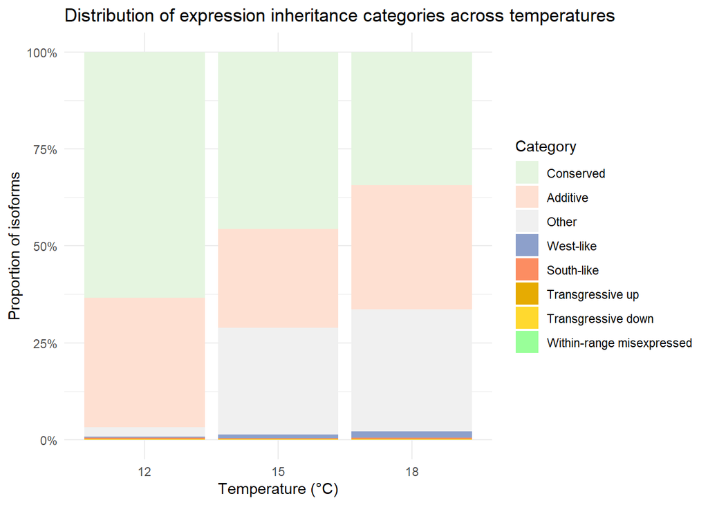

```r
tier3_colors <- c(
  "conserved"                 = "#E5F5E0",
  "additive"                  = "#FEE0D2",
  "other"                     = "#F0F0F0",

  "parent_like_W"             = "#8da0cb",
  "parent_like_S"             = "#fc8d62",

  "within_range_misexpressed" = "#99FF99",
  "transgressive_up"          = "#E6AB02",
  "transgressive_down"        = "#FFD92F"
)

DE_all_plot <- DE_all %>%
  mutate(
    category = factor(
      category,
      levels = c(
        "conserved",
        "additive",
        "other",
        "parent_like_W",
        "parent_like_S",
        "transgressive_up",
        "transgressive_down",
        "within_range_misexpressed"
      )
    )
  )

p_categories <- ggplot(
  DE_all_plot,
  aes(x = factor(temperature), fill = category)
) +
  geom_bar(position = "fill") +
  scale_fill_manual(
    values = tier3_colors,
    breaks = c(
      "conserved",
      "additive",
      "other",
      "parent_like_W",
      "parent_like_S",
      "transgressive_up",
      "transgressive_down",
      "within_range_misexpressed"
    ),
    labels = c(
      "Conserved",
      "Additive",
      "Other",
      "West-like",
      "South-like",
      "Transgressive up",
      "Transgressive down",
      "Within-range misexpressed"
    )
  ) +
  scale_y_continuous(labels = scales::percent) +
  labs(
    x = "Temperature (°C)",
    y = "Proportion of isoforms",
    fill = "Category",
    title = "Distribution of expression inheritance categories across temperatures"
  ) +
  theme_minimal()

p_categories
```

At 12°C, balanced replication (n=5 per origin) meant that DESeq2 produced valid padj values for nearly all isoforms. As a result, our classification function could assign most isoforms cleanly, leading to a large increase in the “conserved” category (86,896) and a much smaller “other” category (3,290). At 15°C and 18°C, however, the lower replication of South origin fish (n=2) limited statistical power in the parental contrast, producing many NA padj values and inflating the “other” category (37,799 and 43,112 isoforms, respectively).

## Visualization: Focus on rare categories

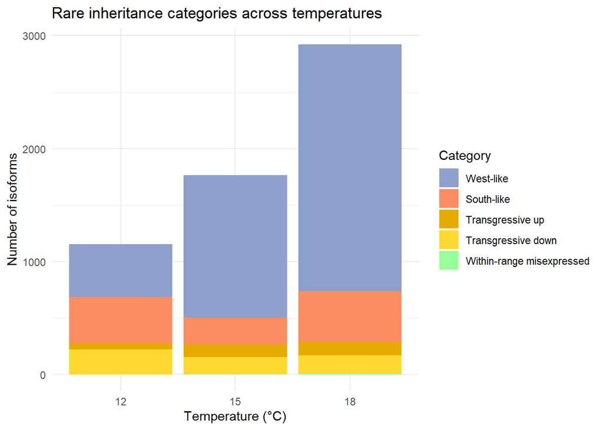

```r
rare_cats <- c(
  "parent_like_S",
  "parent_like_W",
  "transgressive_up",
  "transgressive_down",
  "within_range_misexpressed"
)

DE_rare <- DE_all %>%
  filter(category %in% rare_cats) %>%
  mutate(
    category = factor(
      category,
      levels = c(
        "parent_like_W",
        "parent_like_S",
        "transgressive_up",
        "transgressive_down",
        "within_range_misexpressed"
      )
    )
  )

p_rare <- ggplot(
  DE_rare,
  aes(x = factor(temperature), fill = category)
) +
  geom_bar(position = "stack") +
  scale_fill_manual(
    values = tier3_colors,
    breaks = c(
      "parent_like_W",
      "parent_like_S",
      "transgressive_up",
      "transgressive_down",
      "within_range_misexpressed"
    ),
    labels = c(
      "West-like",
      "South-like",
      "Transgressive up",
      "Transgressive down",
      "Within-range misexpressed"
    )
  ) +
  labs(
    x = "Temperature (°C)",
    y = "Number of isoforms",
    fill = "Category",
    title = "Rare inheritance categories across temperatures"
  ) +
  theme_minimal()

p_rare
```

Most misexpressed isoforms in hybrids show transgressive expression, meaning hybrid expression lies outside the parental range. Transgressive misexpression is widely regarded as the most extreme departure from parental expression and is frequently associated with regulatory incompatibilities and reduced hybrid fitness.

## Export ALL misexpressed isoforms per temperature (combined)

```r
## Export ALL misexpressed isoforms per temperature (combined)

# Ensure output directory exists
dir.create("results/DE/tier3_DE/misexpressed",
           recursive = TRUE,
           showWarnings = FALSE)

mis_cats <- c(
  "transgressive_up",
  "transgressive_down",
  "within_range_misexpressed"
)

for (temp in c(12, 15, 18)) {

  iso <- DE_all %>%
    filter(
      temperature == temp,
      category %in% mis_cats
    ) %>%
    pull(isoform) %>%
    unique()

  write.table(
    iso,
    paste0("results/DE/tier3_DE/misexpressed/misexpressed_", temp, "C.tsv"),
    quote = FALSE,
    row.names = FALSE,
    col.names = FALSE
  )
}
```

## Export parent like isoforms per temperature

```r
# Ensure output directory exists
dir.create("results/DE/tier3_DE/parent_like", recursive = TRUE, showWarnings = FALSE)

for (cat in c("parent_like_S", "parent_like_W")) {
  for (temp in c(12, 15, 18)) {

    iso <- DE_all %>%
      filter(temperature == temp, category == cat) %>%
      pull(isoform) %>%
      unique()

    write.table(
      iso,
      paste0("results/DE/tier3_DE/parent_like/", cat, "_", temp, "C.tsv"),
      quote = FALSE, row.names = FALSE, col.names = FALSE
    )
  }
}
```

## Summarize DE counts per contrast and temperature

```r
contrast_summary <- data.frame()

for (temp in c(12, 15, 18)) {

  # Load contrasts using relative paths
  HS <- read.delim(file.path("results","DE","tier3_DE", paste0("H",temp,"_vs_S",temp,".tsv")))
  HW <- read.delim(file.path("results","DE","tier3_DE", paste0("H",temp,"_vs_W",temp,".tsv")))
  SW <- read.delim(file.path("results","DE","tier3_DE", paste0("S",temp,"_vs_W",temp,".tsv")))

  # Count DE genes (padj < 0.05)
  n_HS <- sum(HS$padj < 0.05, na.rm = TRUE)
  n_HW <- sum(HW$padj < 0.05, na.rm = TRUE)
  n_SW <- sum(SW$padj < 0.05, na.rm = TRUE)

  # Add row
  contrast_summary <- rbind(
    contrast_summary,
    data.frame(
      temperature = temp,
      DE_HS = n_HS,
      DE_HW = n_HW,
      DE_SW = n_SW
    )
  )
}

knitr::kable(contrast_summary, caption = "Counts of DE isoforms per contrast and temperature")
```

Counts of DE isoforms per contrast and temperature

| temperature | DE_HS | DE_HW | DE_SW |
| --- | --- | --- | --- |
| 12 | 1045 | 867 | 1282 |
| 15 | 1924 | 868 | 1798 |
| 18 | 2828 | 1147 | 5490 |

# Build isoform lists for Venn diagrams

```r
mis_list <- list(
  "12°C" = unique(
    DE_all %>%
      filter(
        temperature == 12,
        category %in% c(
          "transgressive_up",
          "transgressive_down",
          "within_range_misexpressed"
        )
      ) %>%
      pull(isoform)
  ),

  "15°C" = unique(
    DE_all %>%
      filter(
        temperature == 15,
        category %in% c(
          "transgressive_up",
          "transgressive_down",
          "within_range_misexpressed"
        )
      ) %>%
      pull(isoform)
  ),

  "18°C" = unique(
    DE_all %>%
      filter(
        temperature == 18,
        category %in% c(
          "transgressive_up",
          "transgressive_down",
          "within_range_misexpressed"
        )
      ) %>%
      pull(isoform)
  )
)

pls_list <- list(
  "12°C" = unique(
    DE_all %>%
      filter(temperature == 12,
             category == "parent_like_S") %>%
      pull(isoform)
  ),

  "15°C" = unique(
    DE_all %>%
      filter(temperature == 15,
             category == "parent_like_S") %>%
      pull(isoform)
  ),

  "18°C" = unique(
    DE_all %>%
      filter(temperature == 18,
             category == "parent_like_S") %>%
      pull(isoform)
  )
)

plw_list <- list(
  "12°C" = unique(
    DE_all %>%
      filter(temperature == 12,
             category == "parent_like_W") %>%
      pull(isoform)
  ),

  "15°C" = unique(
    DE_all %>%
      filter(temperature == 15,
             category == "parent_like_W") %>%
      pull(isoform)
  ),

  "18°C" = unique(
    DE_all %>%
      filter(temperature == 18,
             category == "parent_like_W") %>%
      pull(isoform)
  )
)
```

## Isoform-level overlap across temperatures

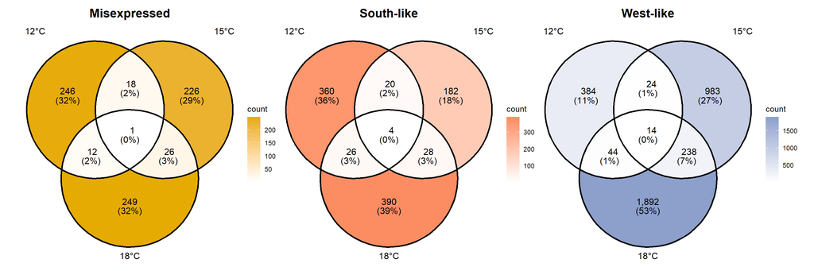

```r
p_mis_iso <-
  ggVennDiagram(mis_list, label_alpha = 0) +
  scale_fill_gradient(low = "white", high = "#E6AB02") +
  ggtitle("Misexpressed") +
  theme(
    plot.title = element_text(
      hjust = 0.5,
      size = 16,
      face = "bold"
    )
  )

p_s_iso <-
  ggVennDiagram(pls_list, label_alpha = 0) +
  scale_fill_gradient(low = "white", high = "#fc8d62") +
  ggtitle("South-like") +
  theme(
    plot.title = element_text(
      hjust = 0.5,
      size = 16,
      face = "bold"
    )
  )

p_w_iso <-
  ggVennDiagram(plw_list, label_alpha = 0) +
  scale_fill_gradient(low = "white", high = "#8da0cb") +
  ggtitle("West-like") +
  theme(
    plot.title = element_text(
      hjust = 0.5,
      size = 16,
      face = "bold"
    )
  )

p_venn_isoforms <- p_mis_iso | p_s_iso | p_w_iso

p_venn_isoforms
```

## Define Tier 3 DE file paths

```r
## Define Tier 3 DE file paths
tier3_files <- list(
  misexpressed_12C   = "results/DE/tier3_DE/misexpressed/misexpressed_12C.tsv",
  misexpressed_15C   = "results/DE/tier3_DE/misexpressed/misexpressed_15C.tsv",
  misexpressed_18C   = "results/DE/tier3_DE/misexpressed/misexpressed_18C.tsv",
  parent_like_S_12C  = "results/DE/tier3_DE/parent_like/parent_like_S_12C.tsv",
  parent_like_S_15C  = "results/DE/tier3_DE/parent_like/parent_like_S_15C.tsv",
  parent_like_S_18C  = "results/DE/tier3_DE/parent_like/parent_like_S_18C.tsv",
  parent_like_W_12C  = "results/DE/tier3_DE/parent_like/parent_like_W_12C.tsv",
  parent_like_W_15C  = "results/DE/tier3_DE/parent_like/parent_like_W_15C.tsv",
  parent_like_W_18C  = "results/DE/tier3_DE/parent_like/parent_like_W_18C.tsv"
)
```

## Load EggNOG transcript‑level annotation

```r
eggnog <- read.delim(
  "results/annotation/eggnog/Trinity.emapper.annotations",
  comment.char = "#",
  header = FALSE,
  sep = "\t",
  stringsAsFactors = FALSE,
  quote = ""
)

colnames(eggnog) <- c(
  "query_name", "seed_ortholog", "evalue", "score", "eggNOG_OGs",
  "max_annot_lvl", "COG_category", "Description", "Preferred_name",
  "GOs", "EC", "KEGG_ko", "KEGG_Pathway", "KEGG_Module",
  "KEGG_Reaction", "KEGG_rclass", "BRITE", "KEGG_TC",
  "CAZy", "BiGG_Reaction", "PFAMs"
)

DT::datatable(
  head(eggnog, 10),
  options = list(pageLength = 5, scrollX = TRUE),
  caption = "Preview of EggNOG transcript-level annotations"
)
```

|  | query_name | seed_ortholog | evalue | score | eggNOG_OGs | max_annot_lvl | COG_category | Description | Preferred_name | GOs | EC | KEGG_ko | KEGG_Pathway | KEGG_Module | KEGG_Reaction | KEGG_rclass | BRITE | KEGG_TC | CAZy | BiGG_Reaction | PFAMs |
| --- | --- | --- | --- | --- | --- | --- | --- | --- | --- | --- | --- | --- | --- | --- | --- | --- | --- | --- | --- | --- | --- |
| 1 | TRINITY_GG_1000_c0_g1_i1.p1 | 8010.XP_010868907.1 | 2.06e-32 | 127 | 2CMAB@1\|root,2QPSQ@2759\|Eukaryota,39XFZ@33154\|Opisthokonta,3BKCQ@33208\|Metazoa,3D5EX@33213\|Bilateria,48CR0@7711\|Chordata,499IK@7742\|Vertebrata,49XUG@7898\|Actinopterygii | 33208\|Metazoa | T | Odorant receptor, family E, subfamily 120, member 1 | - | - | - | ko:K04257 | ko04740,map04740 | - | - | - | ko00000,ko00001,ko04030 | - | - | - | - |
| 2 | TRINITY_GG_1002_c11_g1_i2.p1 | 215358.XP_010730531.1 | 2.16e-304 | 842 | KOG3626@1\|root,KOG3626@2759\|Eukaryota,38DV9@33154\|Opisthokonta,3BCPB@33208\|Metazoa,3CSZS@33213\|Bilateria,489WX@7711\|Chordata,494EU@7742\|Vertebrata,49QSM@7898\|Actinopterygii | 33208\|Metazoa | Q | Solute carrier organic anion transporter family member | SLCO3A1 | GO:0003674,GO:0005215,GO:0005575,GO:0005623,GO:0005886,GO:0005887,GO:0006810,GO:0006811,GO:0006820,GO:0006857,GO:0006869,GO:0008150,GO:0008509,GO:0008514,GO:0009925,GO:0009986,GO:0010876,GO:0015075,GO… | - | ko:K14353,ko:K14356 | - | - | - | - | ko00000,ko02000 | 2.A.60.1 | - | - | OATP |
| 3 | TRINITY_GG_1002_c11_g1_i3.p1 | 215358.XP_010730531.1 | 4.38e-271 | 755 | KOG3626@1\|root,KOG3626@2759\|Eukaryota,38DV9@33154\|Opisthokonta,3BCPB@33208\|Metazoa,3CSZS@33213\|Bilateria,489WX@7711\|Chordata,494EU@7742\|Vertebrata,49QSM@7898\|Actinopterygii | 33208\|Metazoa | Q | Solute carrier organic anion transporter family member | SLCO3A1 | GO:0003674,GO:0005215,GO:0005575,GO:0005623,GO:0005886,GO:0005887,GO:0006810,GO:0006811,GO:0006820,GO:0006857,GO:0006869,GO:0008150,GO:0008509,GO:0008514,GO:0009925,GO:0009986,GO:0010876,GO:0015075,GO… | - | ko:K14353,ko:K14356 | - | - | - | - | ko00000,ko02000 | 2.A.60.1 | - | - | OATP |
| 4 | TRINITY_GG_1002_c11_g1_i4.p1 | 144197.XP_008296061.1 | 1.12e-226 | 640 | KOG3626@1\|root,KOG3626@2759\|Eukaryota,38DV9@33154\|Opisthokonta,3BCPB@33208\|Metazoa,3CSZS@33213\|Bilateria,489WX@7711\|Chordata,494EU@7742\|Vertebrata,49QSM@7898\|Actinopterygii | 33208\|Metazoa | Q | Solute carrier organic anion transporter family member | SLCO3A1 | GO:0003674,GO:0005215,GO:0005575,GO:0005623,GO:0005886,GO:0005887,GO:0006810,GO:0006811,GO:0006820,GO:0006857,GO:0006869,GO:0008150,GO:0008509,GO:0008514,GO:0009925,GO:0009986,GO:0010876,GO:0015075,GO… | - | ko:K14353,ko:K14356 | - | - | - | - | ko00000,ko02000 | 2.A.60.1 | - | - | OATP |
| 5 | TRINITY_GG_1002_c2_g2_i2.p1 | 7955.ENSDARP00000099766 | 6.07e-72 | 244 | KOG1075@1\|root,KOG1075@2759\|Eukaryota,39N4Q@33154\|Opisthokonta,3B9WN@33208\|Metazoa,3D1S8@33213\|Bilateria,48C1W@7711\|Chordata,49N8J@7742\|Vertebrata,4A94B@7898\|Actinopterygii | 33208\|Metazoa | S | Reverse transcriptase (RNA-dependent DNA polymerase) | - | - | - | - | - | - | - | - | - | - | - | - | RVT_1 |
| 6 | TRINITY_GG_1002_c2_g2_i3.p1 | 7955.ENSDARP00000099766 | 6.07e-72 | 244 | KOG1075@1\|root,KOG1075@2759\|Eukaryota,39N4Q@33154\|Opisthokonta,3B9WN@33208\|Metazoa,3D1S8@33213\|Bilateria,48C1W@7711\|Chordata,49N8J@7742\|Vertebrata,4A94B@7898\|Actinopterygii | 33208\|Metazoa | S | Reverse transcriptase (RNA-dependent DNA polymerase) | - | - | - | - | - | - | - | - | - | - | - | - | RVT_1 |
| 7 | TRINITY_GG_1002_c2_g2_i4.p1 | 7955.ENSDARP00000099766 | 6.07e-72 | 244 | KOG1075@1\|root,KOG1075@2759\|Eukaryota,39N4Q@33154\|Opisthokonta,3B9WN@33208\|Metazoa,3D1S8@33213\|Bilateria,48C1W@7711\|Chordata,49N8J@7742\|Vertebrata,4A94B@7898\|Actinopterygii | 33208\|Metazoa | S | Reverse transcriptase (RNA-dependent DNA polymerase) | - | - | - | - | - | - | - | - | - | - | - | - | RVT_1 |
| 8 | TRINITY_GG_1002_c2_g2_i5.p1 | 7955.ENSDARP00000099766 | 6.07e-72 | 244 | KOG1075@1\|root,KOG1075@2759\|Eukaryota,39N4Q@33154\|Opisthokonta,3B9WN@33208\|Metazoa,3D1S8@33213\|Bilateria,48C1W@7711\|Chordata,49N8J@7742\|Vertebrata,4A94B@7898\|Actinopterygii | 33208\|Metazoa | S | Reverse transcriptase (RNA-dependent DNA polymerase) | - | - | - | - | - | - | - | - | - | - | - | - | RVT_1 |
| 9 | TRINITY_GG_1002_c2_g2_i6.p1 | 8083.ENSXMAP00000019809 | 1.42e-64 | 204 | KOG1075@1\|root,KOG1075@2759\|Eukaryota,39Y6T@33154\|Opisthokonta,3BEGN@33208\|Metazoa,3CZ7K@33213\|Bilateria,48DPU@7711\|Chordata,49ADZ@7742\|Vertebrata,4A4QB@7898\|Actinopterygii | 33208\|Metazoa | S | Ribonuclease H protein | - | - | - | - | - | - | - | - | - | - | - | - | - |
| 10 | TRINITY_GG_1002_c2_g2_i7.p1 | 7955.ENSDARP00000099766 | 6.07e-72 | 244 | KOG1075@1\|root,KOG1075@2759\|Eukaryota,39N4Q@33154\|Opisthokonta,3B9WN@33208\|Metazoa,3D1S8@33213\|Bilateria,48C1W@7711\|Chordata,49N8J@7742\|Vertebrata,4A94B@7898\|Actinopterygii | 33208\|Metazoa | S | Reverse transcriptase (RNA-dependent DNA polymerase) | - | - | - | - | - | - | - | - | - | - | - | - | RVT_1 |

## Build gene-level GO annotation table from EggNOG output

```r
## Build gene-level GO annotation table
eggnog_go <- eggnog %>%
  dplyr::filter(GOs != "" & !is.na(GOs)) %>%
  dplyr::select(trinity_id = query_name, GOs) %>%
  dplyr::mutate(
    trinity_id = sub("\\.p[0-9]+$", "", trinity_id),  # remove protein suffix
    gene_id    = sub("_i[0-9]+$", "", trinity_id)     # collapse isoforms → gene
  )

gene2go <- eggnog_go %>%
  tidyr::separate_rows(GOs, sep = ",|;") %>%
  dplyr::mutate(GOs = stringr::str_trim(GOs)) %>%
  dplyr::filter(GOs != "") %>%
  dplyr::distinct(gene_id, GOs)

head(gene2go)
```

```
## # A tibble: 6 × 2
##   gene_id                GOs
##   <chr>                  <chr>
## 1 TRINITY_GG_1000_c0_g1  -
## 2 TRINITY_GG_1002_c11_g1 GO:0003674
## 3 TRINITY_GG_1002_c11_g1 GO:0005215
## 4 TRINITY_GG_1002_c11_g1 GO:0005575
## 5 TRINITY_GG_1002_c11_g1 GO:0005623
## 6 TRINITY_GG_1002_c11_g1 GO:0005886
```

```r
## Universe of annotated genes
universe_genes <- unique(gene2go$gene_id)
```

## Build annotation coverage table and extract gene lists for Venn diagrams

```r
gene_lists <- list()

annotation_summary <- lapply(names(tier3_files), function(lbl) {

  # Load transcript IDs for this Tier 3 category
  df <- read.delim(tier3_files[[lbl]], header = FALSE)
  colnames(df) <- "transcript_id"
  transcripts <- df$transcript_id

  # Collapse isoforms to gene IDs (e.g., TRINITY_DN123_c0_g1_i2 → TRINITY_DN123_c0_g1)
  genes <- unique(sub("_i[0-9]+$", "", transcripts))

  # Store gene IDs for later gene-level Venn diagrams
  gene_lists[[lbl]] <<- genes

  # Count how many transcripts and genes have EggNOG GO annotation
  annotated_transcripts <- sum(transcripts %in% eggnog_go$trinity_id)
  annotated_genes <- sum(genes %in% universe_genes)

  # Return summary row
  data.frame(
    category = lbl,
    total_transcripts = length(transcripts),
    annotated_transcripts = annotated_transcripts,
    percent_transcripts_annot = round(annotated_transcripts / length(transcripts) * 100, 2),
    total_genes = length(genes),
    annotated_genes = annotated_genes,
    percent_genes_annot = round(annotated_genes / length(genes) * 100, 2)
  )
})

annotation_summary <- dplyr::bind_rows(annotation_summary)


datatable(
  annotation_summary,
  extensions = "Buttons",
  options = list(
    dom = "Bfrtip",
    buttons = c("copy", "csv", "excel"),
    pageLength = 10,
    scrollX = TRUE
  ),
  caption = "Annotation Coverage for Tier 3 Differential Expression Categories"
)
```

|  | category | total_transcripts | annotated_transcripts | percent_transcripts_annot | total_genes | annotated_genes | percent_genes_annot |
| --- | --- | --- | --- | --- | --- | --- | --- |
| 1 | misexpressed_12C | 277 | 190 | 68.59 | 269 | 208 | 77.32 |
| 2 | misexpressed_15C | 271 | 204 | 75.28 | 256 | 215 | 83.98 |
| 3 | misexpressed_18C | 288 | 240 | 83.33 | 279 | 252 | 90.32 |
| 4 | parent_like_S_12C | 410 | 280 | 68.29 | 392 | 300 | 76.53 |
| 5 | parent_like_S_15C | 234 | 175 | 74.79 | 222 | 179 | 80.63 |
| 6 | parent_like_S_18C | 448 | 341 | 76.12 | 429 | 363 | 84.62 |
| 7 | parent_like_W_12C | 466 | 322 | 69.1 | 439 | 336 | 76.54 |
| 8 | parent_like_W_15C | 1259 | 1033 | 82.05 | 1154 | 1019 | 88.3 |
| 9 | parent_like_W_18C | 2188 | 1776 | 81.17 | 1994 | 1726 | 86.56 |

# Build gene lists for Venn diagrams

```r
mis_genes <- list(
  "12°C" = gene_lists$misexpressed_12C,
  "15°C" = gene_lists$misexpressed_15C,
  "18°C" = gene_lists$misexpressed_18C
)

pls_genes <- list(
  "12°C" = gene_lists$parent_like_S_12C,
  "15°C" = gene_lists$parent_like_S_15C,
  "18°C" = gene_lists$parent_like_S_18C
)

plw_genes <- list(
  "12°C" = gene_lists$parent_like_W_12C,
  "15°C" = gene_lists$parent_like_W_15C,
  "18°C" = gene_lists$parent_like_W_18C
)
```

## Gene-level overlap across temperatures

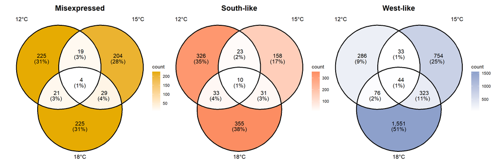

```r
p_mis_gene <-
  ggVennDiagram(mis_genes, label_alpha = 0) +
  scale_fill_gradient(low = "white", high = "#E6AB02") +
  ggtitle("Misexpressed") +
  theme(
    plot.title = element_text(
      hjust = 0.5,
      size = 16,
      face = "bold"
    )
  )

p_s_gene <-
  ggVennDiagram(pls_genes, label_alpha = 0) +
  scale_fill_gradient(low = "white", high = "#fc8d62") +
  ggtitle("South-like") +
  theme(
    plot.title = element_text(
      hjust = 0.5,
      size = 16,
      face = "bold"
    )
  )

p_w_gene <-
  ggVennDiagram(plw_genes, label_alpha = 0) +
  scale_fill_gradient(low = "white", high = "#8da0cb") +
  ggtitle("West-like") +
  theme(
    plot.title = element_text(
      hjust = 0.5,
      size = 16,
      face = "bold"
    )
  )

p_venn_genes <- p_mis_gene | p_s_gene | p_w_gene

p_venn_genes
```

The number of misexpressed genes remains relatively stable across temperatures, suggesting that hybrid misregulation is not strongly temperature‑dependent but represents a consistent background of regulatory incompatibility.

South‑like inheritance shows a dip at 15°C but is otherwise similar across temperature treatments.

West‑like inheritance increases markedly with temperature, indicating a stronger tendency for hybrids to inherit a western population expression under warmer conditions.

The limited overlaps across temperature treatments show that distinct gene sets are involved at each temperature, indicating treatment‑specific regulation rather than a fixed set of misexpressed or parent‑like genes.

## Intersections with Tiers 1 and 2b

### Load Tier 1 and Tier 2b gene sets

```r
# Tier 1: shared temperature-responsive genes
tier1_genes <- read.csv(
  "results/functional_enrichment/tier1_shared_temperature_response/tier1_shared_temperature_genes.csv",
  header = TRUE
)$gene_id

# Tier 2b: thermal local adaptation candidates
tier2b_genes <- read.csv(
  "results/functional_enrichment/tier2_pop_divergence/tier2b_local_adaptation/tier2b_local_adaptation_candidates.csv",
  header = TRUE
)$gene_id
```

### Build Tier 3 gene sets (combined across temperatures)

```r
# Misexpressed genes
misexpressed <- unique(c(
  gene_lists$misexpressed_12C,
  gene_lists$misexpressed_15C,
  gene_lists$misexpressed_18C
))

# Parent-like S genes
parent_like_S <- unique(c(
  gene_lists$parent_like_S_12C,
  gene_lists$parent_like_S_15C,
  gene_lists$parent_like_S_18C
))

# Parent-like W genes
parent_like_W <- unique(c(
  gene_lists$parent_like_W_12C,
  gene_lists$parent_like_W_15C,
  gene_lists$parent_like_W_18C
))
```

### Summary table of tier 3 gene sets (temperature combined)

```r
## Summary table of Tier 3 gene sets
tier3_summary <- data.frame(
  Category = c("Misexpressed", "Parent-like S", "Parent-like W"),
  Count    = c(length(misexpressed),
               length(parent_like_S),
               length(parent_like_W))
)

DT::datatable(
  tier3_summary,
  options = list(pageLength = 5, scrollX = TRUE),
  caption = "Sizes of Tier 3 Gene Sets (combined across temperatures)"
)
```

|  | Category | Count |
| --- | --- | --- |
| 1 | Misexpressed | 727 |
| 2 | Parent-like S | 936 |
| 3 | Parent-like W | 3067 |

### Intersections with Tier 1 and Tier 2b

```r
# Tier 1 intersections
tier1_misexpressed  <- intersect(tier1_genes, misexpressed)
tier1_parent_like_S <- intersect(tier1_genes, parent_like_S)
tier1_parent_like_W <- intersect(tier1_genes, parent_like_W)

# Tier 2b intersections
tier2b_misexpressed  <- intersect(tier2b_genes, misexpressed)
tier2b_parent_like_S <- intersect(tier2b_genes, parent_like_S)
tier2b_parent_like_W <- intersect(tier2b_genes, parent_like_W)
```

### Summary table of Tier 1 & Tier 2b intersections

```r
intersection_summary <- data.frame(
  Category = c("Misexpressed", "Parent-like S", "Parent-like W"),

  Tier1_Count = c(
    length(tier1_misexpressed),
    length(tier1_parent_like_S),
    length(tier1_parent_like_W)
  ),

  Tier2b_Count = c(
    length(tier2b_misexpressed),
    length(tier2b_parent_like_S),
    length(tier2b_parent_like_W)
  )
)

DT::datatable(
  intersection_summary,
  options = list(pageLength = 5, scrollX = TRUE),
  caption = "Summary of Tier 1 and Tier 2b Intersections with Tier 3 Categories"
)
```

|  | Category | Tier1_Count | Tier2b_Count |
| --- | --- | --- | --- |
| 1 | Misexpressed | 23 | 1 |
| 2 | Parent-like S | 37 | 3 |
| 3 | Parent-like W | 146 | 33 |

## Long-format table of all intersected genes

```r
intersection_genes <- list(
  Tier1_Misexpressed   = tier1_misexpressed,
  Tier1_ParentLike_S   = tier1_parent_like_S,
  Tier1_ParentLike_W   = tier1_parent_like_W,
  Tier2b_Misexpressed  = tier2b_misexpressed,
  Tier2b_ParentLike_S  = tier2b_parent_like_S,
  Tier2b_ParentLike_W  = tier2b_parent_like_W
)

intersection_genes_df <- stack(intersection_genes)
colnames(intersection_genes_df) <- c("Gene_ID", "Intersection")

DT::datatable(
  intersection_genes_df,
  options = list(pageLength = 10, scrollX = TRUE),
  caption = "Gene IDs in Each Tier 1 and Tier 2b Intersection"
)
```

|  | Gene_ID | Intersection |
| --- | --- | --- |
| 1 | TRINITY_GG_597_c30_g1 | Tier1_Misexpressed |
| 2 | TRINITY_GG_416_c23_g1 | Tier1_Misexpressed |
| 3 | TRINITY_GG_1219_c1_g1 | Tier1_Misexpressed |
| 4 | TRINITY_GG_957_c157_g1 | Tier1_Misexpressed |
| 5 | TRINITY_GG_866_c19_g1 | Tier1_Misexpressed |
| 6 | TRINITY_GG_722_c7_g3 | Tier1_Misexpressed |
| 7 | TRINITY_GG_165_c3_g1 | Tier1_Misexpressed |
| 8 | TRINITY_GG_225_c3_g1 | Tier1_Misexpressed |
| 9 | TRINITY_GG_1107_c123_g1 | Tier1_Misexpressed |
| 10 | TRINITY_GG_602_c87_g1 | Tier1_Misexpressed |

[output cut: 233 more lines]

## Summary

Most classified isoforms fell into the conserved and additive categories, indicating that hybrid expression was generally similar to or intermediate between parental expression levels.

Most misexpressed isoforms in hybrids showed transgressive expression, meaning that hybrid expression lay outside the parental range. Transgressive misexpression is widely regarded as the most extreme departure from parental expression and is frequently associated with regulatory incompatibilities and reduced hybrid fitness.

The number of misexpressed genes remained relatively stable across temperatures, suggesting that hybrid misexpression is not strongly temperature‑dependent and represents a consistent feature of hybrid gene expression. South‑like inheritance showed a dip at 15°C but was otherwise similar across temperature treatments, while West‑like inheritance increased markedly with temperature, indicating a stronger tendency for hybrids to inherit western population expression under warmer conditions.

The limited overlap across temperature treatments suggests that distinct gene sets are involved at each temperature, indicating temperature‑specific regulation rather than a fixed set of misexpressed or parent‑like genes.

Intersections with Tier 1 and Tier 2b identified twenty‑three misexpressed genes from the conserved temperature‑response gene set and a single misexpressed gene from the local adaptation candidate set. West‑like inheritance showed the largest overlap with both Tier 1 and Tier 2b genes, suggesting that many genes associated with thermal responses also exhibit West‑like expression patterns in hybrids.